# More

## Contents

1. Loading the Database
2. Working With Date Like Objects
1. Comparing Dates
3. Variables in SQL
4. Loop in SQL
5. Functions in SQL
6. Group By
7. More Stuffs
1. String Functions
1. LIKE
2. INSTR

# Loading the Database

```python
%load_ext sql
```

```python
%sql mysql://hari31416:******@localhost:8080/movies
```

Let's see what tables we have:

```python
%sql SHOW TABLES
```

```
 * mysql://hari31416:***@localhost:8080/movies
17 rows affected.
```

| Tables_in_movies |
| --- |
| country |
| department |
| gender |
| genre |
| keyword |
| language |
| language_role |
| movie |
| movie_cast |
| movie_company |
| movie_crew |
| movie_genres |
| movie_keywords |
| movie_languages |
| person |
| production_company |
| production_country |

```python
%%sql
SELECT * FROM movie
LIMIT 5;
```

```
 * mysql://hari31416:***@localhost:8080/movies
5 rows affected.
```

| movie_id | title | budget | homepage | overview | popularity | release_date | revenue | runtime | movie_status | tagline | vote_average | vote_count |
| --- | --- | --- | --- | --- | --- | --- | --- | --- | --- | --- | --- | --- |
| 5 | Four Rooms | 4000000 |  | It's Ted the Bellhop's first night on the job...and the hotel's very unusual guests are about to place him in some outrageous predicaments. It seems that this evening's room service is serving up one … | 22.876230 | 1995-12-09 | 4300000 | 98 | Released | Twelve outrageous guests. Four scandalous requests. And one lone bellhop, in his first day on the job, who's in for the wildest New year's Eve of his life. | 6.50 | 530 |
| 11 | Star Wars | 11000000 | http://www.starwars.com/films/star-wars-episode-iv-a-new-hope | Princess Leia is captured and held hostage by the evil Imperial forces in their effort to take over the galactic Empire. Venturesome Luke Skywalker and dashing captain Han Solo team together with the … | 126.393695 | 1977-05-25 | 775398007 | 121 | Released | A long time ago in a galaxy far, far away... | 8.10 | 6624 |
| 12 | Finding Nemo | 94000000 | http://movies.disney.com/finding-nemo | Nemo, an adventurous young clownfish, is unexpectedly taken from his Great Barrier Reef home to a dentist's office aquarium. It's up to his worrisome father Marlin and a friendly but forgetful fish Do… | 85.688789 | 2003-05-30 | 940335536 | 100 | Released | There are 3.7 trillion fish in the ocean, they're looking for one. | 7.60 | 6122 |
| 13 | Forrest Gump | 55000000 |  | A man with a low IQ has accomplished great things in his life and been present during significant historic events - in each case, far exceeding what anyone imagined he could do. Yet, despite all the t… | 138.133331 | 1994-07-06 | 677945399 | 142 | Released | The world will never be the same, once you've seen it through the eyes of Forrest Gump. | 8.20 | 7927 |
| 14 | American Beauty | 15000000 | http://www.dreamworks.com/ab/ | Lester Burnham, a depressed suburban father in a mid-life crisis, decides to turn his hectic life around after developing an infatuation with his daughter's attractive friend. | 80.878605 | 1999-09-15 | 356296601 | 122 | Released | Look closer. | 7.90 | 3313 |

```python
movie_name = "Star Wars"
```

```python
%sql SELECT * FROM movie WHERE title =:movie_name
```

```
 * mysql://hari31416:***@localhost:8080/movies
1 rows affected.
```

| movie_id | title | budget | homepage | overview | popularity | release_date | revenue | runtime | movie_status | tagline | vote_average | vote_count |
| --- | --- | --- | --- | --- | --- | --- | --- | --- | --- | --- | --- | --- |
| 11 | Star Wars | 11000000 | http://www.starwars.com/films/star-wars-episode-iv-a-new-hope | Princess Leia is captured and held hostage by the evil Imperial forces in their effort to take over the galactic Empire. Venturesome Luke Skywalker and dashing captain Han Solo team together with the … | 126.393695 | 1977-05-25 | 775398007 | 121 | Released | A long time ago in a galaxy far, far away... | 8.10 | 6624 |

# Working With Date Like Objects

The DATE type is used for values with a date part but no time part. MySQL retrieves and displays DATE values in 'YYYY-MM-DD' format. The supported range is '1000-01-01' to '9999-12-31'.

The DATETIME type is used for values that contain both date and time parts. MySQL retrieves and displays DATETIME values in 'YYYY-MM-DD hh:mm:ss' format. The supported range is '1000-01-01 00:00:00' to '9999-12-31 23:59:59'.

The TIMESTAMP data type is used for values that contain both date and time parts. TIMESTAMP has a range of '1970-01-01 00:00:01' UTC to '2038-01-19 03:14:07' UTC.

```python
%%sql
SELECT COUNT(*) as 'number_of_movies',
YEAR(release_date) AS year
FROM movie
GROUP BY year
ORDER BY number_of_movies DESC;
```

```
 * mysql://hari31416:***@localhost:8080/movies
91 rows affected.
```

| number_of_movies | year |
| --- | --- |
| 247 | 2009 |
| 238 | 2014 |
| 237 | 2006 |
| 231 | 2013 |
| 227 | 2008 |
| 225 | 2010 |
| 223 | 2011 |
| 217 | 2005 |
| 216 | 2015 |
| 208 | 2012 |
| 204 | 2004 |
| 203 | 2002 |
| 195 | 2007 |
| 183 | 2001 |
| 171 | 1999 |
| 169 | 2003 |
| 166 | 2000 |
| 133 | 1998 |
| 112 | 1997 |
| 104 | 2016 |
| 97 | 1996 |
| 70 | 1995 |
| 55 | 1994 |
| 47 | 1993 |
| 34 | 1992 |
| 33 | 1981 |
| 32 | 1989 |
| 31 | 1988 |
| 31 | 1987 |
| 30 | 1991 |

[output cut: 61 more lines]

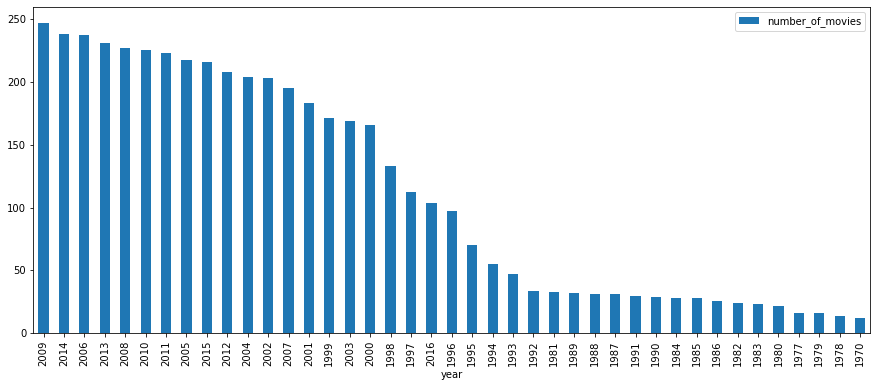

```python
df = _
df = df.DataFrame()
df[df["number_of_movies"]>10].plot(x='year', y='number_of_movies', kind='bar', figsize=(15,6))
```

```python
%%sql
SELECT COUNT(*) as 'number_of_movies',
MONTH(release_date) AS month
FROM movie
GROUP BY month
ORDER BY number_of_movies DESC;
```

```
 * mysql://hari31416:***@localhost:8080/movies
13 rows affected.
```

| number_of_movies | month |
| --- | --- |
| 588 | 9 |
| 474 | 10 |
| 456 | 12 |
| 413 | 8 |
| 389 | 6 |
| 382 | 1 |
| 372 | 3 |
| 363 | 5 |
| 363 | 7 |
| 350 | 4 |
| 326 | 11 |
| 326 | 2 |
| 1 | 0 |

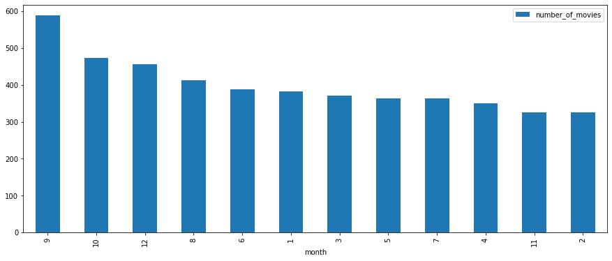

```python
df = _
df = df.DataFrame()
df[df["number_of_movies"]>10].plot(x='month', y='number_of_movies', kind='bar', figsize=(15,6))
```

```python
%%sql
SELECT COUNT(*) as 'number_of_movies',
WEEKDAY(release_date) AS day_num
FROM movie
GROUP BY day_num
ORDER BY number_of_movies DESC;
```

```
 * mysql://hari31416:***@localhost:8080/movies
8 rows affected.
```

| number_of_movies | day_num |
| --- | --- |
| 2053 | 4 |
| 916 | 3 |
| 795 | 2 |
| 351 | 1 |
| 237 | 5 |
| 233 | 0 |
| 217 | 6 |
| 1 | None |

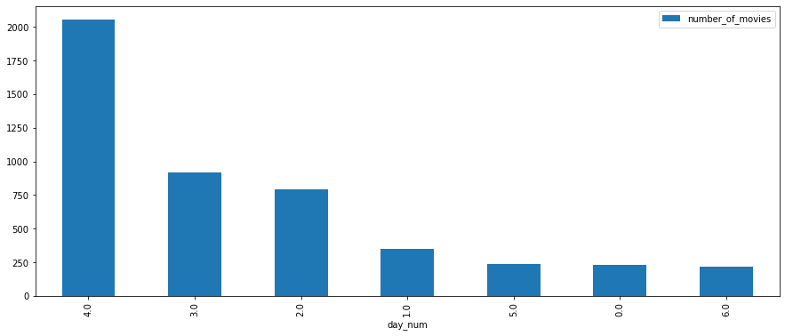

```python
df = _
df = df.DataFrame()
df[df["number_of_movies"]>10].plot(x='day_num', y='number_of_movies', kind='bar', figsize=(15,6));
```

### Comparing Dates

Comparing Dates is easy. Just use the right format: `YYYY-MM-DD`.

```python
%%sql
SELECT release_date
FROM movie
WHERE release_date > ('2010-12-22')
ORDER BY release_date ASC
LIMIT 5;
```

```
 * mysql://hari31416:***@localhost:8080/movies
5 rows affected.
```

| release_date |
| --- |
| 2010-12-23 |
| 2010-12-25 |
| 2010-12-27 |
| 2010-12-29 |
| 2011-01-01 |

```python
%%sql
SELECT release_date
FROM movie
WHERE release_date > DATE('2010-12-22')
ORDER BY release_date ASC
LIMIT 5;
```

```
 * mysql://hari31416:***@localhost:8080/movies
5 rows affected.
```

| release_date |
| --- |
| 2010-12-23 |
| 2010-12-25 |
| 2010-12-27 |
| 2010-12-29 |
| 2011-01-01 |

# Variables in SQL

Variables are used to store values that can be used in a SQL statement. Variables are created using the SET statement. The syntax for the SET statement is:

```
SET @var_name = expression
```

```python
%sql SET @string = "Hello World";
```

```
 * mysql://hari31416:***@localhost:8080/movies
0 rows affected.
```

```
[]
```

```python
%sql SELECT @string as 'string';
```

```
 * mysql://hari31416:***@localhost:8080/movies
1 rows affected.
```

| string |
| --- |
| Hello World |

```python
%%sql
SET @int = 10;
SET @int = @int + 1;
SELECT @int as 'int';
```

```
 * mysql://hari31416:***@localhost:8080/movies
0 rows affected.
0 rows affected.
1 rows affected.
```

| int |
| --- |
| 11 |

We can even access a non existing variable and it will be created for us setting its value to NULL.

```python
%sql SELECT @var3;
```

```
 * mysql://hari31416:***@localhost:8080/movies
1 rows affected.
```

| @var3 |
| --- |
| None |

There are other ways to create variables. We can define a variable and set it to a value inside a query by using `:=` operator. For example:

```
SELECT @var_name := expression
```

```python
%sql SELECT @var3 := 10;
```

```
 * mysql://hari31416:***@localhost:8080/movies
1 rows affected.
```

| @var3 := 10 |
| --- |
| 10 |

We can use the variables to create a ranking system for movies based on `vote_average`.

```python
%sql SELECT vote_average FROM movie LIMIT 5;
```

```
 * mysql://hari31416:***@localhost:8080/movies
5 rows affected.
```

| vote_average |
| --- |
| 6.50 |
| 8.10 |
| 7.60 |
| 8.20 |
| 7.90 |

```python
%%sql
SET @rank = 0;
SET @rating=0;

SELECT title, if (@rating!=vote_average, @rank:=@rank+1, @rank) as 'rank'
FROM movie
ORDER BY vote_average DESC

LIMIT 10;
```

```
 * mysql://hari31416:***@localhost:8080/movies
0 rows affected.
0 rows affected.
10 rows affected.
```

| title | rank |
| --- | --- |
| Stiff Upper Lips | 1 |
| Dancer, Texas Pop. 81 | 2 |
| Little Big Top | 3 |
| Me You and Five Bucks | 4 |
| Sardaarji | 5 |
| One Man's Hero | 6 |
| There Goes My Baby | 7 |
| The Shawshank Redemption | 8 |
| The Godfather | 9 |
| The Prisoner of Zenda | 10 |

# Loop in SQL

```python
%sql DROP PROCEDURE IF EXISTS doiterate
```

```
 * mysql://hari31416:***@localhost:8080/movies
0 rows affected.
```

```
[]
```

```python
%%sql
CREATE PROCEDURE doiterate(p1 INT)
BEGIN
  label1: LOOP
    SET p1 = p1 + 1;
    IF p1 < 10 THEN
      ITERATE label1;
    END IF;
    LEAVE label1;
  END LOOP label1;
  SET @x = p1;
--   RETURN p1;
  SELECT @x>10;
    SELECT p1;
END;
```

```
 * mysql://hari31416:***@localhost:8080/movies
0 rows affected.
```

```
[]
```

```python
%%sql
CALL doiterate(85);
```

```
 * mysql://hari31416:***@localhost:8080/movies
1 rows affected.
```

| @x>10 |
| --- |
| 1 |

# Functions in SQL

The `CREATE FUNCTION` statement is used for creating a stored function and user-defined functions. A stored function is a set of SQL statements that perform some operation and return a single value.

The syntax for the `CREATE FUNCTION` statement is:

```
CREATE FUNCTION function_name(func_parameter1, func_parameter2, ..)
          RETURN datatype [characteristics]
          func_body
```

func_body is the set of Mysql statements that perform operation. It’s structure is as follows:

```
BEGIN
        Mysql Statements
        RETURN expression;
END
```

```python
%sql DROP FUNCTION IF EXISTS sum_two_numbers;
```

```
 * mysql://hari31416:***@localhost:8080/movies
0 rows affected.
```

```
[]
```

```python
%%sql
CREATE FUNCTION sum_two_numbers(value1 INT, value2 INT)
RETURNS INT
DETERMINISTIC
BEGIN
    RETURN value1 + value2;
END
```

```
 * mysql://hari31416:***@localhost:8080/movies
0 rows affected.
```

```
[]
```

```python
%%sql
SELECT sum_two_numbers(10,20);
```

```
 * mysql://hari31416:***@localhost:8080/movies
1 rows affected.
```

| sum_two_numbers(10,20) |
| --- |
| 30 |

Suppose we want to categorize movies as success or failure based on their `budget` and `revenue`. We can create a function that returns a string based on the condition.

```python
%sql DROP FUNCTION IF EXISTS success
```

```
 * mysql://hari31416:***@localhost:8080/movies
0 rows affected.
```

```
[]
```

```python
%%sql
CREATE FUNCTION success(b INT, r INT)
RETURNS VARCHAR(20)
DETERMINISTIC
BEGIN
DECLARE result VARCHAR(20);
IF 2*b < r THEN
SET result = 'success';
ELSE
SET result = 'failure';
END IF;
RETURN result;
END;
```

```
 * mysql://hari31416:***@localhost:8080/movies
0 rows affected.
```

```
[]
```

```python
%%sql
SELECT title, success(budget, revenue) as 'Result'
FROM movie
LIMIT 15;
```

```
 * mysql://hari31416:***@localhost:8080/movies
15 rows affected.
```

| title | Result |
| --- | --- |
| Four Rooms | failure |
| Star Wars | success |
| Finding Nemo | success |
| Forrest Gump | success |
| American Beauty | success |
| Dancer in the Dark | success |
| The Fifth Element | success |
| Metropolis | failure |
| My Life Without Me | success |
| Pirates of the Caribbean: The Curse of the Black Pearl | success |
| Kill Bill: Vol. 1 | success |
| Jarhead | failure |
| Apocalypse Now | success |
| Unforgiven | success |
| The Simpsons Movie | success |

Of course, this can easily be done using a `CASE` statement:

```python
%%sql
SELECT title,
CASE
WHEN 2*budget < revenue THEN 'success'
ELSE 'failure'
END AS 'Result'
FROM movie
LIMIT 15;
```

```
 * mysql://hari31416:***@localhost:8080/movies
15 rows affected.
```

| title | Result |
| --- | --- |
| Four Rooms | failure |
| Star Wars | success |
| Finding Nemo | success |
| Forrest Gump | success |
| American Beauty | success |
| Dancer in the Dark | success |
| The Fifth Element | success |
| Metropolis | failure |
| My Life Without Me | success |
| Pirates of the Caribbean: The Curse of the Black Pearl | success |
| Kill Bill: Vol. 1 | success |
| Jarhead | failure |
| Apocalypse Now | success |
| Unforgiven | success |
| The Simpsons Movie | success |

# Group By

The `GROUP BY` statement groups rows that have the same values into summary rows, like "find the number of customers in each country".

The `GROUP BY` statement is often used with aggregate functions (`COUNT()`, `MAX()`, `MIN()`, `SUM()`, `AVG()`) to group the result-set by one or more columns.

```
SELECT column_name(s)
FROM table_name
WHERE condition
GROUP BY column_name(s)
ORDER BY column_name(s);
```

```python
%%sql
SELECT * FROM movie LIMIT 5;
```

```
 * mysql://hari31416:***@localhost:8080/movies
5 rows affected.
```

| movie_id | title | budget | homepage | overview | popularity | release_date | revenue | runtime | movie_status | tagline | vote_average | vote_count |
| --- | --- | --- | --- | --- | --- | --- | --- | --- | --- | --- | --- | --- |
| 5 | Four Rooms | 4000000 |  | It's Ted the Bellhop's first night on the job...and the hotel's very unusual guests are about to place him in some outrageous predicaments. It seems that this evening's room service is serving up one … | 22.876230 | 1995-12-09 | 4300000 | 98 | Released | Twelve outrageous guests. Four scandalous requests. And one lone bellhop, in his first day on the job, who's in for the wildest New year's Eve of his life. | 6.50 | 530 |
| 11 | Star Wars | 11000000 | http://www.starwars.com/films/star-wars-episode-iv-a-new-hope | Princess Leia is captured and held hostage by the evil Imperial forces in their effort to take over the galactic Empire. Venturesome Luke Skywalker and dashing captain Han Solo team together with the … | 126.393695 | 1977-05-25 | 775398007 | 121 | Released | A long time ago in a galaxy far, far away... | 8.10 | 6624 |
| 12 | Finding Nemo | 94000000 | http://movies.disney.com/finding-nemo | Nemo, an adventurous young clownfish, is unexpectedly taken from his Great Barrier Reef home to a dentist's office aquarium. It's up to his worrisome father Marlin and a friendly but forgetful fish Do… | 85.688789 | 2003-05-30 | 940335536 | 100 | Released | There are 3.7 trillion fish in the ocean, they're looking for one. | 7.60 | 6122 |
| 13 | Forrest Gump | 55000000 |  | A man with a low IQ has accomplished great things in his life and been present during significant historic events - in each case, far exceeding what anyone imagined he could do. Yet, despite all the t… | 138.133331 | 1994-07-06 | 677945399 | 142 | Released | The world will never be the same, once you've seen it through the eyes of Forrest Gump. | 8.20 | 7927 |
| 14 | American Beauty | 15000000 | http://www.dreamworks.com/ab/ | Lester Burnham, a depressed suburban father in a mid-life crisis, decides to turn his hectic life around after developing an infatuation with his daughter's attractive friend. | 80.878605 | 1999-09-15 | 356296601 | 122 | Released | Look closer. | 7.90 | 3313 |

```python
%%sql
SELECT COUNT(*) as 'number_of_movies', runtime
FROM movie as m
GROUP BY runtime
HAVING COUNT(*) > 100
ORDER BY number_of_movies DESC
LIMIT 5;
```

```
 * mysql://hari31416:***@localhost:8080/movies
5 rows affected.
```

| number_of_movies | runtime |
| --- | --- |
| 163 | 90 |
| 149 | 100 |
| 140 | 98 |
| 133 | 97 |
| 123 | 95 |

# More Stuffs

## String Functions

### `LIKE`

```python
%%sql
SELECT m.title
FROM movie as m
WHERE m.title LIKE 'S%' and m.title LIKE '%s'
LIMIT 10;
```

```
 * mysql://hari31416:***@localhost:8080/movies
10 rows affected.
```

| title |
| --- |
| Star Wars |
| Star Trek: Generations |
| Star Trek: Nemesis |
| Snow White and the Seven Dwarfs |
| Starship Troopers |
| Sleepers |
| Spaceballs |
| Street Kings |
| Shortbus |
| Superman Returns |

### `INSTR`

The `INSTR()` function returns the position of the first occurrence of a string in another string.

This function performs a case-insensitive search.

```python
%%sql
SELECT INSTR('Hello World', 'World');
```

```
 * mysql://hari31416:***@localhost:8080/movies
1 rows affected.
```

| INSTR('Hello World', 'World') |
| --- |
| 7 |

If no match are found, the function returns 0.

```python
%%sql
SELECT INSTR('Hello World', 'Worlda');
```

```
 * mysql://hari31416:***@localhost:8080/movies
1 rows affected.
```

| INSTR('Hello World', 'Worlda') |
| --- |
| 0 |

We can use this function to get a list of movies that do not contain the letter `s` in their title.

```python
%%sql
SELECT m.title
FROM movie as m
WHERE INSTR(m.title, 's') = 0
LIMIT 10;
```

```
 * mysql://hari31416:***@localhost:8080/movies
10 rows affected.
```

| title |
| --- |
| Finding Nemo |
| American Beauty |
| Dancer in the Dark |
| The Fifth Element |
| My Life Without Me |
| Kill Bill: Vol. 1 |
| Jarhead |
| Unforgiven |
| 8 Mile |
| Brazil |